# ARIMA

Владимир Агеев

```r
library(forecast)
library(Rssa)
```

# AR(p) – модель, запись в виде с оператором сдвига

AR(p) – авторегрессия порядка p имеет форму $x_t = c + \sum\limits_{i = 1}^p\varphi_ix_{t - i} + \epsilon_t$, $\epsilon_t$ ~ $N(0, \sigma^2)$ – независимы с $x_s$, $s \leq t$.

AR многочлен: $\phi(z) = \sum\limits_{i = 1}^p\varphi_iz^i$, $\varphi_p \neq 0$.

Если корни по модулю больше единицы, то соответсвтующий ряд стационарный.

## Запись через оператор сдвига

Оператор сдвига $Lx_t = x_{t - 1}$, тогда эквивалентная запись AR(p): $\Phi(L)x_t = (1 - \sum\limits_{i = 1}^p\varphi_iL^i)x_t = \epsilon_t$.

# AR(p) и модель сигнала в SSA

- В AR(p) ошибка добавляется на каждом шаге
- В SSA сигнал отделяется от шума: $X_t = S_t + \epsilon_t$

# Вид автоковариационной функции AR(p)

## Автоковариационная функция AR(1):

$x_t = c + \varphi x_{t-1} + \epsilon_t$.

$E(x_t) = c + \varphi E(x_{t-1})$, следовательно $E(x_t) = c/(1 -\varphi)$.

$Dx_t = \varphi^2 Dx_{t-1} + \sigma^2$, $Dx_t = \sigma^2/(1 - \varphi^2)$.

$v(h) = cov(x_t, x_{t-h}) = \frac{\sigma^2}{(1 - \varphi^2)}\varphi^h$.

## Общий случай

$x_t = \sum\limits_{i =1}^p \varphi_i x_{t-i} + \epsilon_t$

$v(h) = cov(x_t, x_{t - h}) = \sum\limits_{i =1}^p \varphi_i E(x_{t-i}x_{t-h}) = \sum\limits_{i =1}^p \varphi_i v(h - i)$, $h \geq p$.

- Если все корни $\phi(z)$ вещественные, то $v(h)$ экспоненциально убывает к 0 при $h \rightarrow \infty$
- Если есть комплексные корни, то $v(h)$ – экспоненциально убывающий к 0 синус при $h \rightarrow \infty$

# Вид pacf AR(p)

$pacf(m) = corr(x_{t + m} - \widehat{x}_{t + m}, x_{t} - \widehat{x}_{t})$

$\widehat{x}_{t}$ – регрессия $x_t$ на $\{x_{t+1}, x_{t+2}, \ldots, x_{t + h - 1}\}$.

$\widehat{x}_{t+ h}$ – регрессия $x_{t+h}$ на $\{x_{t + h - 1}, x_{t + h - 2}, \ldots, x_{t+1}\}$.

# Модель MA(q), acf, pcf

$x_t = \epsilon_t + \sum\limits_{i = 1}^q \theta_i\epsilon_{t - i}$

Эквивалентная запись:

$x_t = (1 + \sum\limits_{i = 1}^q \theta_iL^i)\epsilon_t = \Theta(L)\epsilon_t$

# ARMA(p, q)

$x_t$ – ARMA(p,q), если это стационарный ряд и $\Phi(L)x_t = \Theta(L)\epsilon_t$.

# ARIMA(p, d, q)

$x_t$ – ARIMA(p, d, q), если $\Phi(L)(1 - L)^d x_t = \Theta(L)\epsilon_t$.

# Seasonal ARIMA

$ARMA(P, Q)_s$ имеет форму $\Phi_P(L^s)x_t = \Theta_Q(L^s)\epsilon_t$, где

$\Phi_P(L^s) = 1 - \sum\limits_{i = 1}^P\Phi_iL^{is}$, $\Theta_Q(L^s) = 1 + \sum\limits_{i = 1}^Q\Theta_iL^{is}$.

$ARMA(p,q)\times(P,Q)_s$:

$\Phi_P(L^s)\phi(L)x_t = \Theta_Q(L^s)\theta(L)\epsilon_t$

SARIMA:

Сезонная разность порядка D:

$\nabla^D_sx_t = (1 - L^s)^Dx_t$

$ARIMA(p,d,q)\times(P,D,Q)_s$:

$\Phi_P(L^s)\phi(L)\nabla^D_s(1 - L)^dx_t = \Theta_Q(L^s)\theta(L)\epsilon_t$

Исходный ряд

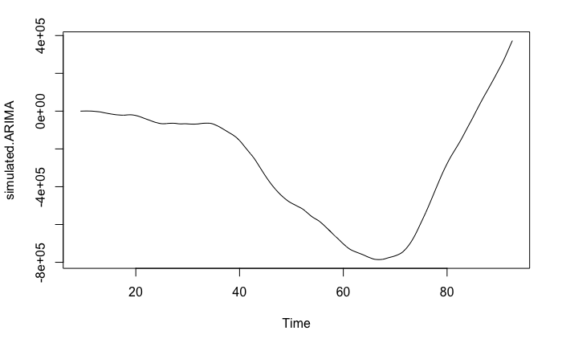

```r
set.seed(100)
model <- Arima(ts(rnorm(100), freq=12), order=c(2,2,1), seasonal=c(1,0,1),
               fixed = c(phi1 = 0.8, phi2 = 0.1, theta = 0.7, Phi=0.3, Theta=-0.2))
simulated.ARIMA <- simulate(model, nsim=1000)
plot(simulated.ARIMA)
```

# Дифференцирование

Дважды дифференцируем

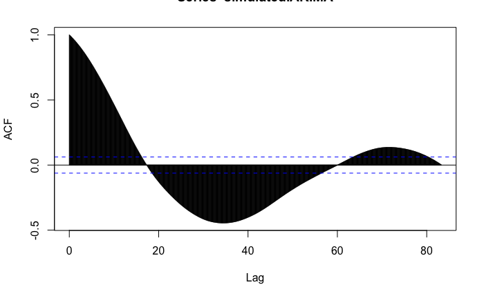

```r
acf(simulated.ARIMA, lag.max = 1000)
```

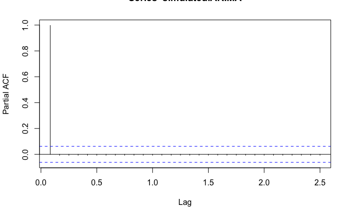

```r
pacf(simulated.ARIMA)
```

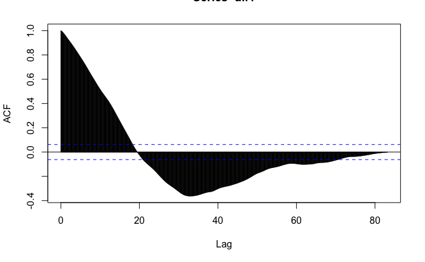

```r
dif1 <- diff(simulated.ARIMA)
acf(dif1, lag.max = 1000)
```

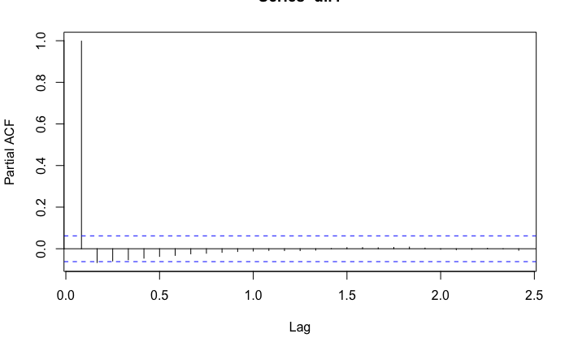

```r
pacf(dif1)
```

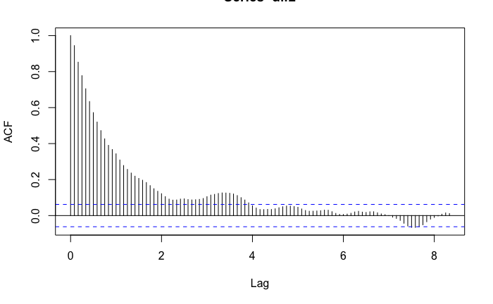

```r
dif2 <- diff(dif1)
acf(dif2, lag.max = 100)
```

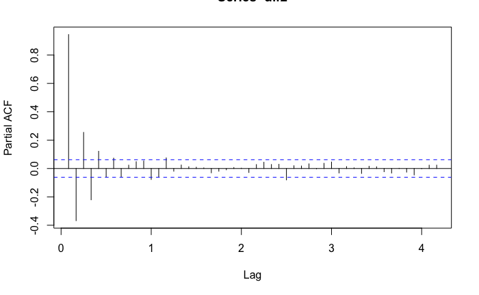

```r
pacf(dif2, lag.max = 50)
```

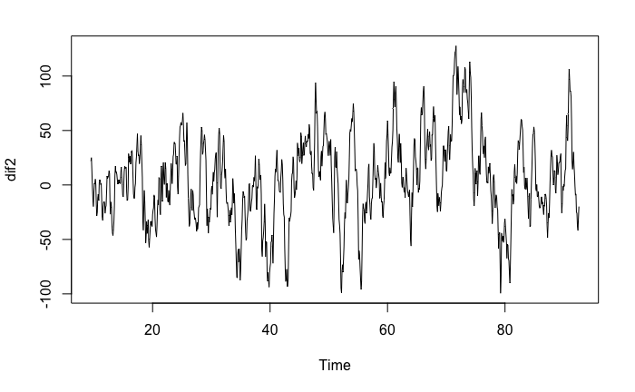

```r
plot(dif2)
```

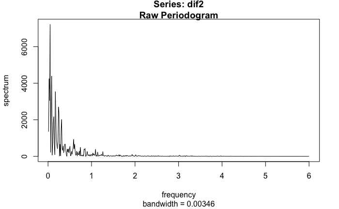

```r
spec.pgram(dif2, log = 'no')
```

# Оценка параметров

```r
auto.fit <- auto.arima(simulated.ARIMA, trace = TRUE, stepwise = FALSE, seasonal = TRUE)
```

```
 ARIMA(0,2,0)                    : 10154.83
 ARIMA(0,2,0)(0,0,1)[12]                    : 10032.37
 ARIMA(0,2,0)(0,0,2)[12]                    : 10029.09
 ARIMA(0,2,0)(1,0,0)[12]                    : 10032.41
 ARIMA(0,2,0)(1,0,1)[12]                    : 10034.38
 ARIMA(0,2,0)(1,0,2)[12]                    : 10032.14
 ARIMA(0,2,0)(2,0,0)[12]                    : 10043.87
 ARIMA(0,2,0)(2,0,1)[12]                    : 10044.8
 ARIMA(0,2,0)(2,0,2)[12]                    : 10041.54
 ARIMA(0,2,1)                    : 8962.146
 ARIMA(0,2,1)(0,0,1)[12]                    : 8841.036
 ARIMA(0,2,1)(0,0,2)[12]                    : 8837.167
 ARIMA(0,2,1)(1,0,0)[12]                    : 8850.294
 ARIMA(0,2,1)(1,0,1)[12]                    : 8851.519
 ARIMA(0,2,1)(1,0,2)[12]                    : 8853.226
 ARIMA(0,2,1)(2,0,0)[12]                    : 8851.036
 ARIMA(0,2,1)(2,0,1)[12]                    : 8850.87
 ARIMA(0,2,1)(2,0,2)[12]                    : 8848.271
 ARIMA(0,2,2)                    : 8326.366
 ARIMA(0,2,2)(0,0,1)[12]                    : 8248.516
 ARIMA(0,2,2)(0,0,2)[12]                    : 8247.7
 ARIMA(0,2,2)(1,0,0)[12]                    : 8257.396
 ARIMA(0,2,2)(1,0,1)[12]                    : 8258.983
 ARIMA(0,2,2)(1,0,2)[12]                    : 8260.494
 ARIMA(0,2,2)(2,0,0)[12]                    : 8271.539
 ARIMA(0,2,2)(2,0,1)[12]                    : 8271.809
 ARIMA(0,2,3)                    : 8072.184
 ARIMA(0,2,3)(0,0,1)[12]                    : 8007.384
 ARIMA(0,2,3)(0,0,2)[12]                    : 8006.905
 ARIMA(0,2,3)(1,0,0)[12]                    : 8023.631
 ARIMA(0,2,3)(1,0,1)[12]                    : 8024.291
 ARIMA(0,2,3)(2,0,0)[12]                    : 8024.163
 ARIMA(0,2,4)                    : 7918.157
 ARIMA(0,2,4)(0,0,1)[12]                    : 7870.026
 ARIMA(0,2,4)(1,0,0)[12]                    : 7881.659
 ARIMA(0,2,5)                    : 7811.21
 ARIMA(1,2,0)                    : 7914.825
 ARIMA(1,2,0)(0,0,1)[12]                    : 7906.403
 ARIMA(1,2,0)(0,0,2)[12]                    : 7907.775
 ARIMA(1,2,0)(1,0,0)[12]                    : 7910.555
```

[output cut: 41 more lines]

```
 ARIMA(3,2,0)                    : 7707.058
 ARIMA(3,2,0)(0,0,1)[12]                    : 7695.698
 ARIMA(3,2,0)(0,0,2)[12]                    : 7697.189
 ARIMA(3,2,0)(1,0,0)[12]                    : 7701.885
 ARIMA(3,2,0)(1,0,1)[12]                    : 7703.671
 ARIMA(3,2,0)(2,0,0)[12]                    : 7709.531
 ARIMA(3,2,1)                    : 7636.548
 ARIMA(3,2,1)(0,0,1)[12]                    : 7624.421
 ARIMA(3,2,1)(1,0,0)[12]                    : 7631.084
 ARIMA(3,2,2)                    : 7638.443
 ARIMA(4,2,0)                    : 7658.571
 ARIMA(4,2,0)(0,0,1)[12]                    : 7642.828
 ARIMA(4,2,0)(1,0,0)[12]                    : 7647.85
 ARIMA(4,2,1)                    : 7634.719
 ARIMA(5,2,0)                    : 7645.797
```

```r
summary(auto.fit)
```

```
Series: simulated.ARIMA
ARIMA(1,2,2)(0,0,1)[12]

Coefficients:
         ar1     ma1      ma2    sma1
      0.9038  0.5885  -0.0945  0.1220
s.e.  0.0156  0.0356   0.0343  0.0314

sigma^2 estimated as 122.1:  log likelihood=-3813.46
AIC=7636.91   AICc=7636.97   BIC=7661.44

Training set error measures:
                    ME     RMSE      MAE       MPE      MAPE         MASE         ACF1
Training set 0.2677498 11.01796 8.749342 0.1039329 0.1755073 0.0003723221 0.0002137927
```

# Прогноз

```r
arima.prediction <- predict(auto.fit, 300)
plot(simulated.ARIMA, xlim = c(0,120), ylim = c(-8e+05, 5e+05))
lines(arima.prediction$pred, col = 'red')
```

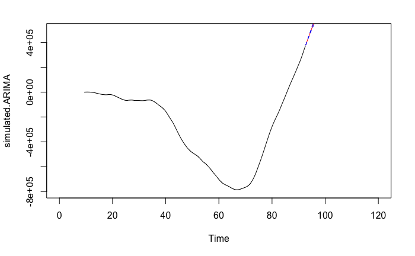

```r
lines(arima.prediction$pred + arima.prediction$se, lty = 'dashed', col = 'blue')
lines(arima.prediction$pred - arima.prediction$se, lty = 'dashed', col = 'blue')
```

```r
plot(simulated.ARIMA, xlim = c(80,120), ylim = c(0, 8e+05))
lines(arima.prediction$pred, col = 'red')
```

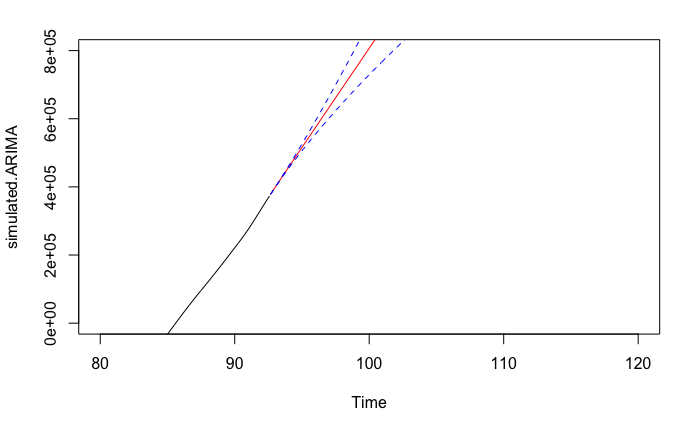

```r
lines(arima.prediction$pred + arima.prediction$se, lty = 'dashed', col = 'blue')
lines(arima.prediction$pred - arima.prediction$se, lty = 'dashed', col = 'blue')
```

# SARIMA vs SSA

```r
uk <- read.csv("UK.csv", sep = ',', stringsAsFactors = FALSE)
uk <- ts(uk$EXPEND, start = c(1980, 1), frequency = 12)
```

## SSA

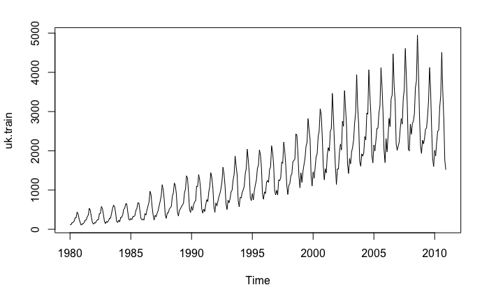

```r
uk.train <- head(uk, -72)
plot(uk.train)
```

```r
uk.train.ssa <- ssa(uk.train, L = 24)
uk.train.trend <- reconstruct(uk.train.ssa, groups = 1)
uk.train.detrended <- residuals(uk.train.trend)
uk.train.detrended.ssa <- ssa(uk.train.detrended, L = 180)
uk.train.seasonality <- reconstruct(uk.train.detrended.ssa, groups = list(1:9))
```

```r
uk.trend.forecast <- predict(uk.train.ssa, method = "bootstrap-recurrent", len = 72, groups = 1)
uk.seasonality.forecast <- predict(uk.train.detrended.ssa, method = "bootstrap-recurrent", len = 72, groups = list(1:9))
plot(uk, xlim = c(2010, 2018))
lines(uk.trend.forecast[,1] + uk.seasonality.forecast[,1], col = 'red')
```

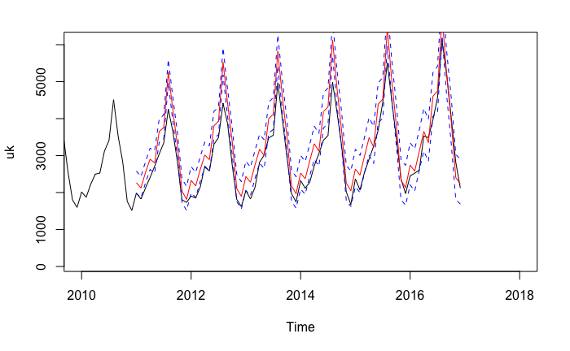

```r
lines(uk.trend.forecast[,2] + uk.seasonality.forecast[,2], col = 'blue',lty="dashed")
lines(uk.trend.forecast[,3] + uk.seasonality.forecast[,3], col = 'blue',lty="dashed")
```

MSE

```r
sum((tail(uk,72) - (uk.trend.forecast[,1] + uk.seasonality.forecast[,1]))^2)/72
```

```
[1] 236810
```

MSE прогноза на год

```r
sum((tail(uk,72)[1:12] - (uk.trend.forecast[1:12,1] + uk.seasonality.forecast[1:12,1]))^2)/12
```

```
[1] 228522.2
```

## SARIMA

```r
auto.fit.uk <- auto.arima(uk.train, trace = TRUE, stepwise = FALSE, allowdrift = FALSE)
```

```
 ARIMA(0,0,0)(0,1,0)[12]                    : 4609.677
 ARIMA(0,0,0)(0,1,1)[12]                    : 4605.92
 ARIMA(0,0,0)(0,1,2)[12]                    : 4570.102
 ARIMA(0,0,0)(1,1,0)[12]                    : 4613.276
 ARIMA(0,0,0)(1,1,1)[12]                    : Inf
 ARIMA(0,0,0)(1,1,2)[12]                    : Inf
 ARIMA(0,0,0)(2,1,0)[12]                    : 4575.118
 ARIMA(0,0,0)(2,1,1)[12]                    : Inf
 ARIMA(0,0,0)(2,1,2)[12]                    : Inf
 ARIMA(0,0,1)(0,1,0)[12]                    : 4507.381
 ARIMA(0,0,1)(0,1,1)[12]                    : 4508.452
 ARIMA(0,0,1)(0,1,2)[12]                    : 4485.141
 ARIMA(0,0,1)(1,1,0)[12]                    : 4519.165
 ARIMA(0,0,1)(1,1,1)[12]                    : 4513.546
 ARIMA(0,0,1)(1,1,2)[12]                    : Inf
 ARIMA(0,0,1)(2,1,0)[12]                    : 4500.653
 ARIMA(0,0,1)(2,1,1)[12]                    : Inf
 ARIMA(0,0,1)(2,1,2)[12]                    : Inf
 ARIMA(0,0,2)(0,1,0)[12]                    : 4437.354
 ARIMA(0,0,2)(0,1,1)[12]                    : 4430.973
 ARIMA(0,0,2)(0,1,2)[12]                    : 4420.724
 ARIMA(0,0,2)(1,1,0)[12]                    : 4438.837
 ARIMA(0,0,2)(1,1,1)[12]                    : 4436.083
 ARIMA(0,0,2)(1,1,2)[12]                    : Inf
 ARIMA(0,0,2)(2,1,0)[12]                    : 4442.367
 ARIMA(0,0,2)(2,1,1)[12]                    : Inf
 ARIMA(0,0,3)(0,1,0)[12]                    : 4420.287
 ARIMA(0,0,3)(0,1,1)[12]                    : 4405.62
 ARIMA(0,0,3)(0,1,2)[12]                    : 4397.304
 ARIMA(0,0,3)(1,1,0)[12]                    : 4411.34
 ARIMA(0,0,3)(1,1,1)[12]                    : 4411.748
 ARIMA(0,0,3)(2,1,0)[12]                    : 4422.04
 ARIMA(0,0,4)(0,1,0)[12]                    : 4401.569
 ARIMA(0,0,4)(0,1,1)[12]                    : 4382.084
 ARIMA(0,0,4)(1,1,0)[12]                    : 4386.684
 ARIMA(0,0,5)(0,1,0)[12]                    : 4383.458
 ARIMA(1,0,0)(0,1,0)[12]                    : 4407.718
 ARIMA(1,0,0)(0,1,1)[12]                    : 4344.179
 ARIMA(1,0,0)(0,1,2)[12]                    : 4340.676
 ARIMA(1,0,0)(1,1,0)[12]                    : 4357.705
```

[output cut: 41 more lines]

```
 ARIMA(3,0,0)(0,1,0)[12]                    : 4354.896
 ARIMA(3,0,0)(0,1,1)[12]                    : 4293.657
 ARIMA(3,0,0)(0,1,2)[12]                    : 4291.62
 ARIMA(3,0,0)(1,1,0)[12]                    : 4306.162
 ARIMA(3,0,0)(1,1,1)[12]                    : 4303.185
 ARIMA(3,0,0)(2,1,0)[12]                    : 4316.591
 ARIMA(3,0,1)(0,1,0)[12]                    : 4350.227
 ARIMA(3,0,1)(0,1,1)[12]                    : 4280.178
 ARIMA(3,0,1)(1,1,0)[12]                    : 4293.699
 ARIMA(3,0,2)(0,1,0)[12]                    : 4350.246
 ARIMA(4,0,0)(0,1,0)[12]                    : 4347.801
 ARIMA(4,0,0)(0,1,1)[12]                    : 4286.691
 ARIMA(4,0,0)(1,1,0)[12]                    : 4298.339
 ARIMA(4,0,1)(0,1,0)[12]                    : 4349.489
 ARIMA(5,0,0)(0,1,0)[12]                    : 4350.566
```

```r
summary(auto.fit.uk)
```

```
Series: uk.train
ARIMA(1,0,1)(0,1,2)[12]

Coefficients:
         ar1      ma1     sma1    sma2
      0.9694  -0.5597  -0.4820  0.1018
s.e.  0.0143   0.0565   0.0568  0.0467

sigma^2 estimated as 11689:  log likelihood=-2196.63
AIC=4403.27   AICc=4403.44   BIC=4422.7

Training set error measures:
                   ME     RMSE      MAE        MPE     MAPE     MASE       ACF1
Training set 7.828414 105.7642 74.95484 -0.1452581 6.010407 0.594552 0.02306655
```

Выбранная модель – ARIMA(1,0,1)x(0,1,2) с периодом 12

Прогноз

```r
arima.prediction.uk <- predict(auto.fit.uk, 72)
plot(uk, xlim = c(2010, 2018))
lines(arima.prediction.uk$pred, col = 'red')
```

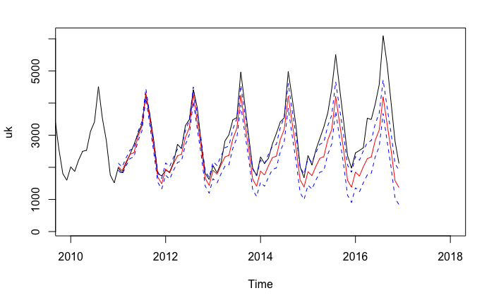

```r
lines(arima.prediction.uk$pred + arima.prediction.uk$se, lty = 'dashed', col = 'blue')
lines(arima.prediction.uk$pred - arima.prediction.uk$se, lty = 'dashed', col = 'blue')
```

MSE длинного прогноза

```r
sum((tail(uk,72) - arima.prediction.uk$pred)^2)/72
```

```
[1] 477969.6
```

Ошибка больше чем в случае SSA.

MSE годового прогноза

```r
sum((tail(uk,72)[1:12] - arima.prediction.uk$pred[1:12])^2)/12
```

```
[1] 18694.75
```

Ошибка гораздо меньше чем у SSA!

Вывод:

- Для коротких прогнозов ARIMA, возможно, подойдет лучше чем SSA
- Для длинных прогнозов SSA показывает намного лучший результат